# Data Science Project

## Sequence Data

This sequence data is a collection of DNA sequences of the entire ITS gene region in Angiosperm and Gymnosperm species pulled from online databases. This set of [data](https://github.com/rosatiem98/rosatiem98.github.io/blob/859c3a36f1475da382ad317598b7b1769f2bd096/DNA%20extraction%20sequences.docx) is a collection of DNA sequences gathered through DNA extraction and amplification of the ITS gene region in herbarium specimens.

The analysis preformed will be done with a small DNA data set with 19 samples from the extraction DNA and samples from the online database DNA. In total a data set of 399 sequences are analyzed. Number of sequences are [species](https://github.com/rosatiem98/rosatiem98.github.io/blob/9027bb5a2635ec01c4091367c3b9e4804ab42a94/number_of_hits.tsv) of interest and sequences that were not unique or duplicated were removed.

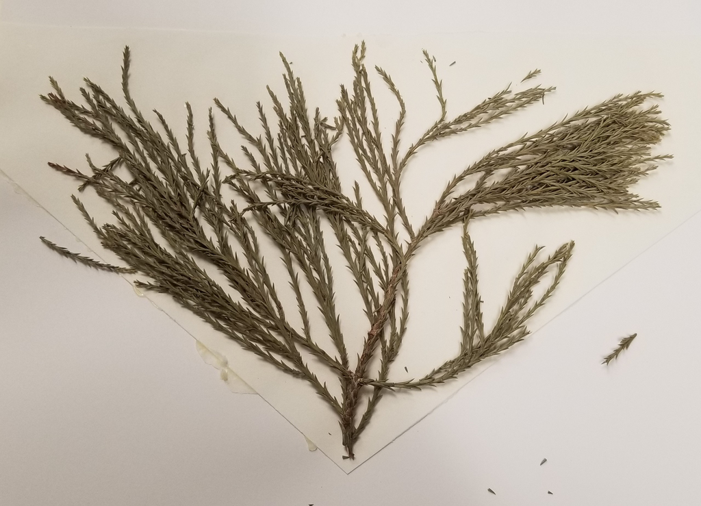

Herbarium Specimen

The purpose of this analysis is to determine the evolutionary differences between angiosperm and gymnosperm specimens. From analyzing differences, a phylogenetic tree is built around the ITS gene region of these two groups.

## Read in dataset from small research dataset FASTA file

```r
myspecies <- readDNAStringSet("./Interested Species ITS 2.fasta")
```

```r
un <- unique(myspecies)

align399 <- readRDS("./finalproject/subset_msa_align.RDS")
```

## Example Alignment of sequences #196:206

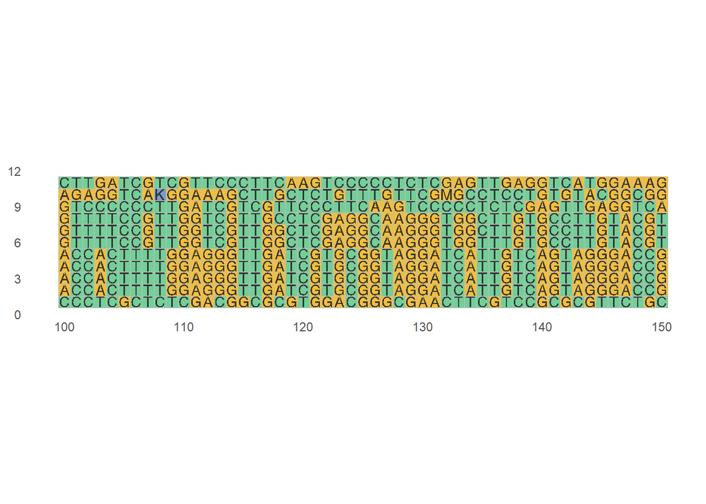

```r
shortggmsa <- ggmsa(myspecies[196:206], start=100, end = 150)
shortggmsa
```

## Alignment of research sequences

unspecies <- msa(un)

```r
align399 <- readRDS("./finalproject/subset_msa_align.RDS")
msa399 <- as.phyDat(align399,type="DNA")
```

## Conduct model test

mt399 <- modelTest(msa399)

```r
mt399 <- readRDS("./modeltest_399.RDs")

dist399 <- dist.ml(msa399, model="JC69")

msa399_UPGMA <- upgma(dist399)

parsimony(msa399_UPGMA,msa399)
```

```
## [1] 29158
```

```r
msa399_NJ <- NJ(dist399)

parsimony(msa399_NJ,msa399)
```

```
## [1] 29664
```

```r
msa399_optim <- optim.parsimony(msa399_UPGMA,msa399)
```

```
## Final p-score 27197 after  60 nni operations
```

```r
msa399_optim <- readRDS("./msa399_optim")
```

msa399_pratchet <- pratchet(msa399)

```r
msa399_pratchet <- readRDS("./msa399_pranchet")

fit399 <- pml(msa399_UPGMA,msa399)
```

fit399JC <- optim.pml(fit399, model=“JC”, rearrangement = “stochastic”)

```r
fit399JC <- readRDS("./fit399JC.RDS")
```

logLik(fit399JC)

## Build a phylogenetic tree with bootsttrap values

bs399 <- bootstrap.pml(fit399JC,bs=100, optNni=TRUE, multicore=TRUE, control = pml.control(trace=0))

## Initial tree

[figure not shown]

## Let’s clean the names of the tips

## Cleaning the Tip labels

```r
genus195 <- tre$tip.label[1:195] %>% str_split(" ") %>% map_chr(2)
species195 <- tre$tip.label[1:195] %>% str_split(" ") %>% map_chr(3)
names195 <- paste0(genus195," ",species195)


genus197 <- tre$tip.label[197] %>% str_split(" ") %>% map_chr(2)
species197 <- tre$tip.label[197] %>% str_split(" ") %>% map_chr(3)
names197 <- paste0(genus197," ",species197)

genus315 <- tre$tip.label[199:315] %>% str_split(" ") %>% map_chr(2)
species315 <- tre$tip.label[199:315] %>% str_split(" ") %>% map_chr(3)
names315 <- paste0(genus315," ",species315)

genus321 <- tre$tip.label[320:321] %>% str_split(" ") %>% map_chr(2)
species321 <- tre$tip.label[320:321] %>% str_split(" ") %>% map_chr(3)
names321 <- paste0(genus321," ",species321)

genus324 <- tre$tip.label[323:324] %>% str_split(" ") %>% map_chr(2)
species324 <- tre$tip.label[323:324] %>% str_split(" ") %>% map_chr(3)
names324 <- paste0(genus324," ",species324)

genus328 <- tre$tip.label[328] %>% str_split("") %>% map_chr(1)
species328 <- tre$tip.label[328] %>% str_split("Â") %>% map_chr(2)
names328 <- paste0(genus328," ",species328)


genus330 <- tre$tip.label[330] %>% str_split(" ") %>% map_chr(2)
species330 <- tre$tip.label[330] %>% str_split(" ") %>% map_chr(3)
names330 <- paste0(genus330," ",species330)

genus396 <- tre$tip.label[336:396] %>% str_split(" ") %>% map_chr(2)
species396 <- tre$tip.label[336:396] %>% str_split(" ") %>% map_chr(3)
names396 <- paste0(genus396," ",species396)

genus399 <- tre$tip.label[399] %>% str_split(" ") %>% map_chr(2)
species399 <- tre$tip.label[399] %>% str_split(" ") %>% map_chr(3)
names399 <- paste0(genus399," ",species399)

tre$tip.label[1:195] <- names195
tre$tip.label[197] <- names197
tre$tip.label[199:315] <- names315
tre$tip.label[320:321] <- names321
tre$tip.label[323:324] <- names324
tre$tip.label[328] <- names328
tre$tip.label[330] <- names330
tre$tip.label[336:396] <- names396
tre$tip.label[399] <- names399
```

## Exploring Phylogenetic trees

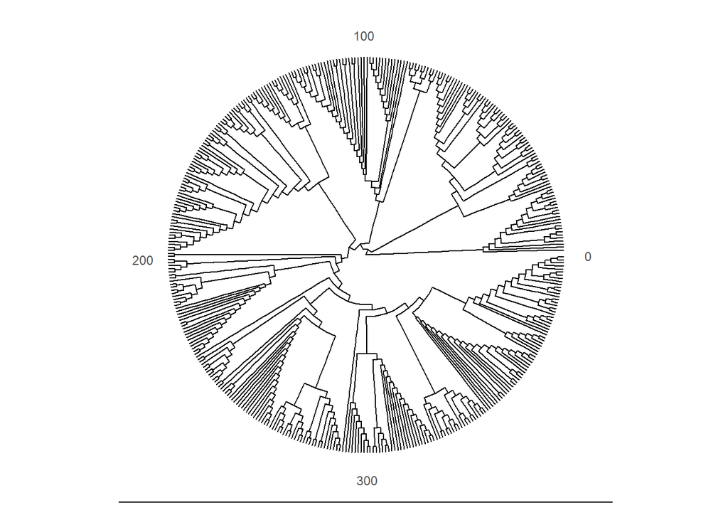

```r
circle_tree <- ggtree(tre, branch.length = "none", layout ="circular") + theme_tree2()
circle_tree
```

```r
ggsave(filename = "circle_tree.png")
square_tree <- ggtree(tre) + geom_tree() + theme_tree2()
ggsave(filename = "square_tree.png")
```

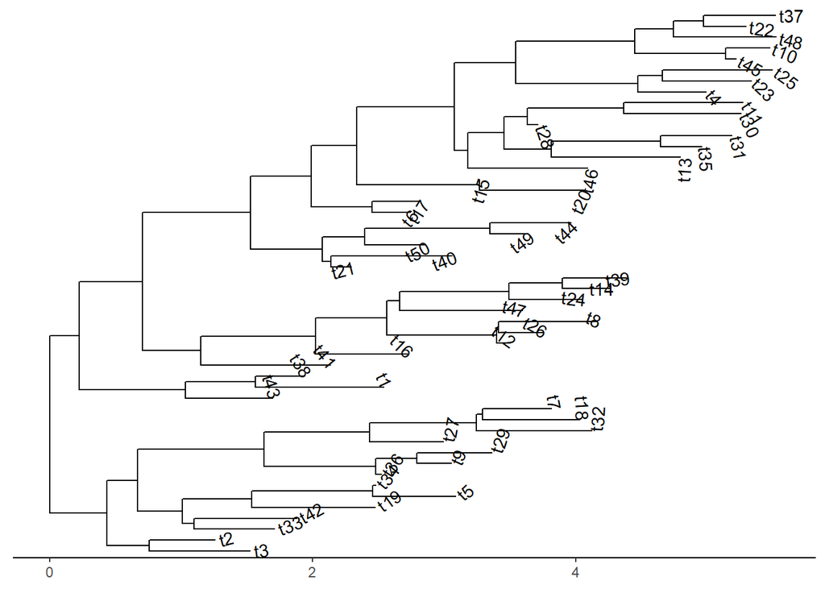

```r
tree50 <- rtree(50)

ggtree(tree50) + theme_tree2() + geom_tiplab2()
```

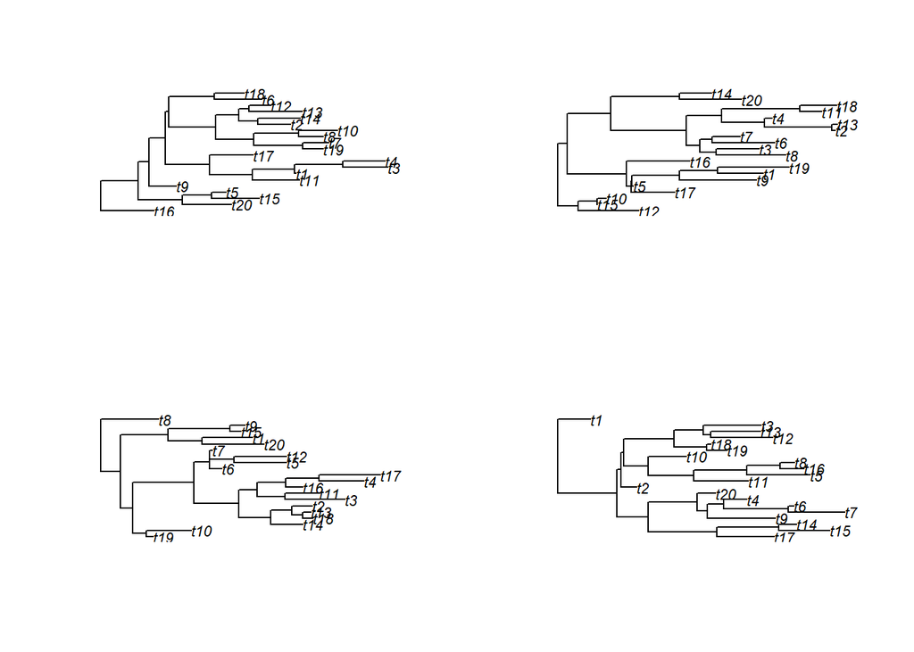

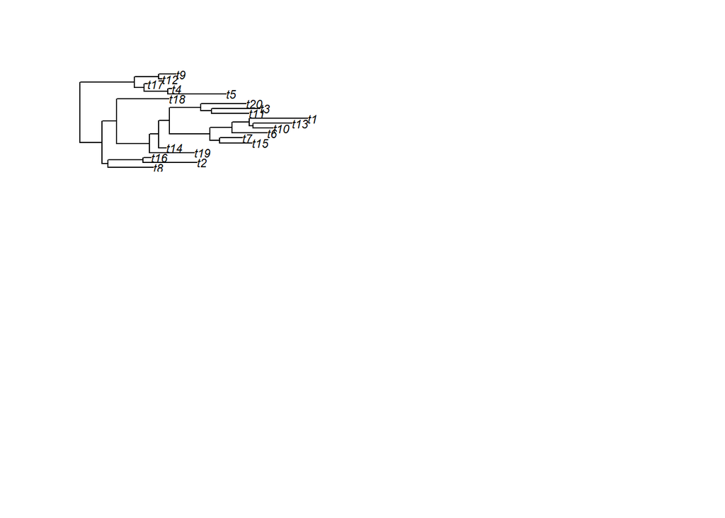

```r
#Creating 5 separate random trees using rtree function



data(tre)
layout(matrix(1:4, 2,2))
for (i in 1:5) plot(rtree(20))
```

## Observations and conclusions

This project’s purpose was to gather full ITS gene sequences from angiosperm and gymnosperm species and build a phylogeny with the aligned sequences. This was accomplished on a foundational level. In the future the relationships within the trees observed will be further analyzed through further phylogenetic analysis and tree manipulation.